# Bycatch Manuscript - Revision

Shawn Dsouza

25 March 2020

# 1 Composition of sea snakes in bycatch

## 1.1 Sampling effort

| Year | Jan | Feb | Mar | Apr | May | Oct | Nov | Dec |
| --- | --- | --- | --- | --- | --- | --- | --- | --- |
| 2016 | 2 | 8 | 8 | 3 | 6 | NA | 4 | 10 |
| 2017 | 12 | 19 | 15 | NA | NA | NA | 1 | 6 |
| 2018 | 91 | 56 | 59 | 15 | 22 | 18 | 41 | 44 |

| Year | Jan | Feb | Mar | Apr | May | Oct | Nov | Dec |
| --- | --- | --- | --- | --- | --- | --- | --- | --- |
| 2016 | 9.00 | 29.00 | 28.00 | 16.00 | 29.00 | NA | 13.00 | 36.50 |
| 2017 | 57.00 | 100.50 | 48.00 | NA | NA | NA | 0.00 | 15.00 |
| 2018 | 255.91 | 163.78 | 156.88 | 37.63 | 51.63 | 43.51 | 73.26 | 114.88 |

| Gear.Type | n.trips | sampling.effort |
| --- | --- | --- |
| GillNet | 329 | 916.57 |
| Trawler | 65 | 449.16 |

Sampling was not conducted trip wise for 2016 and most of 2017. Hence, effort data is unavailable.

## 1.2 Assemblage composition

| Species | 2016 | 2017 | 2018 |
| --- | --- | --- | --- |
| Acrochordus granulatus | NA | 1 | NA |
| Hydrophis curtus | 75 | 38 | 123 |
| Hydrophis cyanocinctus | NA | NA | 3 |
| Hydrophis schistosus | 178 | 215 | 521 |
| Hydrophis viperinus | NA | 1 | 1 |

## 1.3 Abundacne accross years

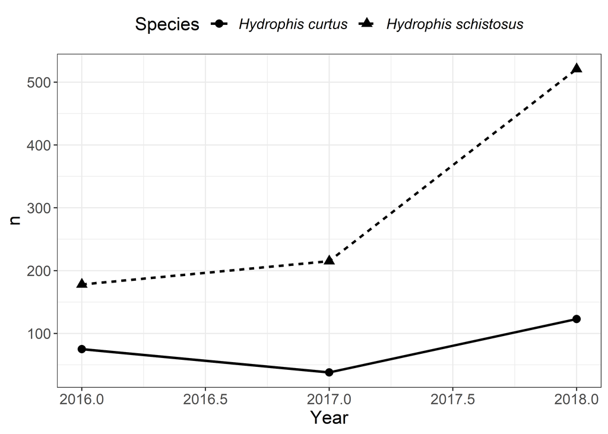

Sampling effort is uneven, which may explain the difference in abundance

| estimate1 | estimate2 | estimate3 | statistic | p.value |
| --- | --- | --- | --- | --- |
| 0.2964427 | 0.1501976 | 0.1909938 | 18.40334 | 0.0001009 |

Assemblage composition is significantly different accross years.

## 1.4 Varition in CPUE across years by gear

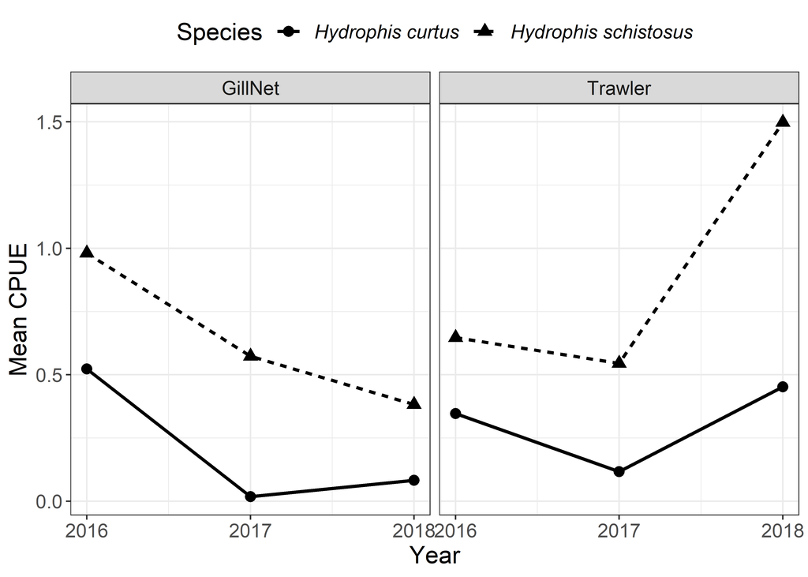

| Gear.Type | Hydrophis curtus | Hydrophis schistosus |
| --- | --- | --- |
| GillNet | 0.1310796 | 0.4591615 |
| Trawler | 0.2660660 | 0.9251351 |

| Species | term | estimate | std.error | statistic | p.value | pseudo.r2 |
| --- | --- | --- | --- | --- | --- | --- |
| Hydrophis curtus | (Intercept) | -2.0319508 | 0.1566218 | -12.973615 | 0.0000000 | 0.0220098 |
| Hydrophis curtus | Gear.TypeTrawler | 0.7079399 | 0.2885418 | 2.453509 | 0.0141470 | 0.0220098 |
| Hydrophis schistosus | (Intercept) | -0.7783534 | 0.0836829 | -9.301221 | 0.0000000 | 0.0749735 |
| Hydrophis schistosus | Gear.TypeTrawler | 0.7005379 | 0.1545698 | 4.532180 | 0.0000058 | 0.0749735 |

| Gear.Type | term | estimate | std.error | statistic | p.value | pseudo.r2 |
| --- | --- | --- | --- | --- | --- | --- |
| GillNet | (Intercept) | -2.031951 | 0.1566218 | -12.973615 | 0.0e+00 | 0.1550399 |
| GillNet | SpeciesHydrophis schistosus | 1.253597 | 0.1775760 | 7.059499 | 0.0e+00 | 0.1550399 |
| Trawler | (Intercept) | -1.324011 | 0.2423344 | -5.463569 | 0.0e+00 | 0.1503309 |
| Trawler | SpeciesHydrophis schistosus | 1.246195 | 0.2749825 | 4.531907 | 5.8e-06 | 0.1503309 |

## 1.5 Seasonal variation in CPUE

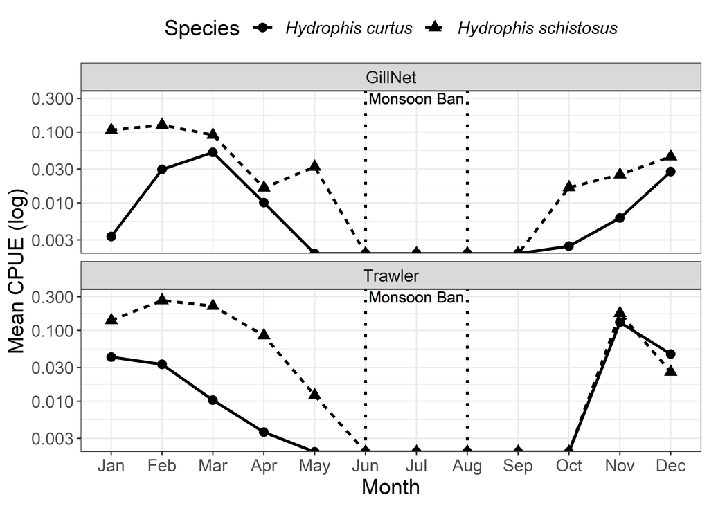

- Show gap in sampling
- Mean CPUE shoulb be independent of effort

| Gear.Type | Species | (Intercept) | MonthApr | MonthDec | MonthFeb | MonthMar | MonthMay | MonthNov | MonthOct |
| --- | --- | --- | --- | --- | --- | --- | --- | --- | --- |
| GillNet | Hydrophis curtus | 0.0135373 | 0.2487249 | 0.1733922 | 0.1484227 | 0.2588770 | -0.0135373 | 0.0660315 | 0.0373717 |
| GillNet | Hydrophis schistosus | 0.4303169 | -0.0059075 | -0.1245967 | 0.2562562 | 0.0509318 | 0.0483775 | -0.1056459 | -0.0879338 |
| Trawler | Hydrophis curtus | 0.1584076 | -0.0799762 | 0.4349257 | -0.0568203 | -0.1071256 | -0.1584076 | 1.9249257 | NA |
| Trawler | Hydrophis schistosus | 0.5233512 | 1.2914637 | -0.1900178 | 0.2883160 | 0.5672471 | 0.2544266 | 2.2766488 | NA |

| Gear.Type | Species | LR Chisq | Df | Pr(>Chisq) |
| --- | --- | --- | --- | --- |
| GillNet | Hydrophis curtus | 11.80502 | 7 | 0.1071561 |
| GillNet | Hydrophis schistosus | 12.92839 | 7 | 0.0738724 |
| Trawler | Hydrophis curtus | 31.81082 | 6 | 0.0000177 |
| Trawler | Hydrophis schistosus | 15.74299 | 6 | 0.0152020 |

## 1.6 Length distribution in bycatch

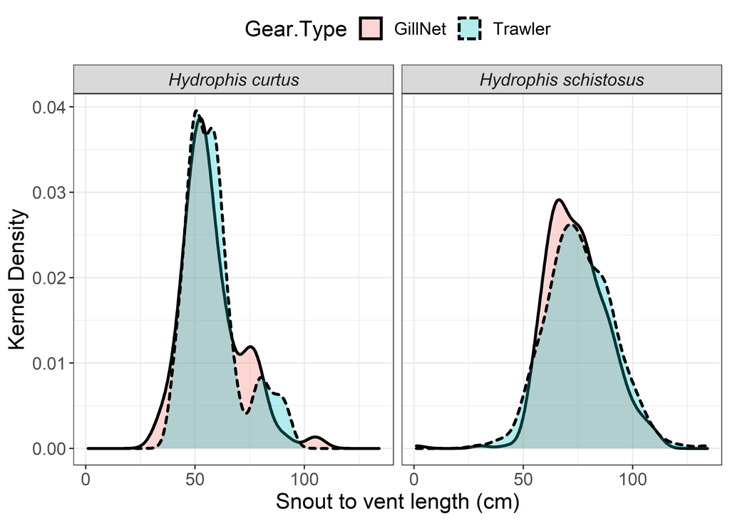

No selectivity of SVL in either gear.

- Does mesh size affect catch composition?

**Variable type: numeric**

| skim_variable | Species | n_missing | complete_rate | mean | sd | p0 | p25 | p50 | p75 | p100 | hist |
| --- | --- | --- | --- | --- | --- | --- | --- | --- | --- | --- | --- |
| Snout.to.Vent..cm. | Hydrophis curtus | 89 | 0.62 | 58.07 | 12.77 | 34.5 | 49.0 | 55.5 | 63.75 | 105.0 | ▃▇▃▂▁ |
| Snout.to.Vent..cm. | Hydrophis schistosus | 203 | 0.78 | 74.36 | 15.01 | 1.0 | 64.5 | 73.5 | 84.85 | 134.2 | ▁▁▇▃▁ |

| Species | estimate | estimate1 | estimate2 | statistic | p.value | d |
| --- | --- | --- | --- | --- | --- | --- |
| Hydrophis curtus | -0.6316698 | 57.60896 | 58.24063 | -0.2802908 | 0.7797036 | 0.0489142 |
| Hydrophis schistosus | -1.6728765 | 74.32615 | 75.99903 | -1.4689341 | 0.1423528 | 0.1155450 |

## 1.7 Sex distibution in bycatch

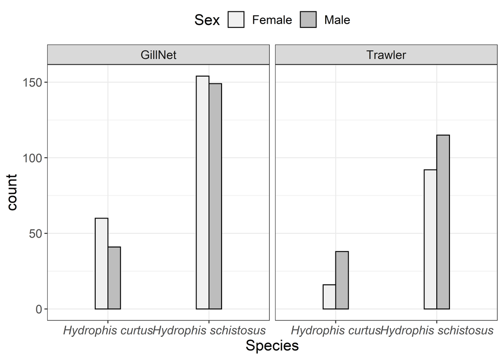

| Species | estimate1 | estimate2 | p.value | conf.low | conf.high | r |
| --- | --- | --- | --- | --- | --- | --- |
| Hydrophis curtus | 0.5940594 | 0.2962963 | 0.0007665 | 0.1286188 | 0.4669074 | 0.0730372 |
| Hydrophis schistosus | 0.5082508 | 0.4444444 | 0.1848910 | -0.0282980 | 0.1559108 | 0.0034468 |

Significantly more male *H. curtus* caught in trawler than gillnets

# 2 Effect of effort on composition of sea snakes

| Gear.Type | n |
| --- | --- |
| GillNet | 255 |
| Trawler | 27 |

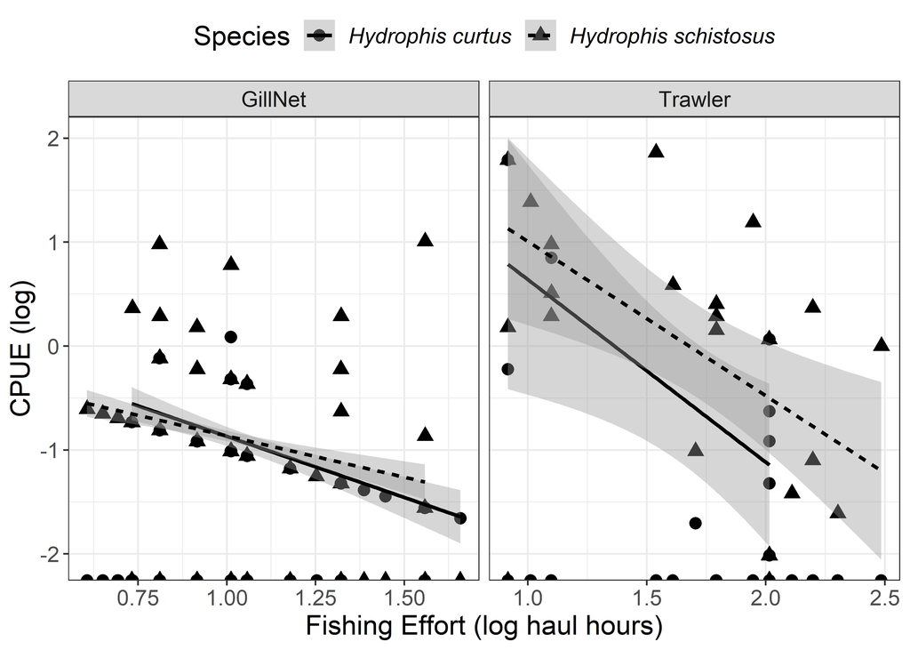

| Gear.Type | Species | term | estimate | std.error | statistic | p.value | pseudo.r2 |
| --- | --- | --- | --- | --- | --- | --- | --- |
| GillNet | Hydrophis curtus | (Intercept) | -2.4112310 | 1.1590687 | -2.0803177 | 0.0374964 | 0.0001834 |
| GillNet | Hydrophis curtus | fe | -0.0458745 | 0.4050654 | -0.1132520 | 0.9098308 | 0.0001834 |
| GillNet | Hydrophis schistosus | (Intercept) | -0.3203169 | 0.5576728 | -0.5743814 | 0.5657097 | 0.0219099 |
| GillNet | Hydrophis schistosus | fe | -0.2320209 | 0.1990205 | -1.1658141 | 0.2436896 | 0.0219099 |
| Trawler | Hydrophis curtus | (Intercept) | 1.5190270 | 0.6702299 | 2.2664268 | 0.0234253 | 0.3097021 |
| Trawler | Hydrophis curtus | fe | -0.4806118 | 0.1610280 | -2.9846476 | 0.0028391 | 0.3097021 |
| Trawler | Hydrophis schistosus | (Intercept) | 1.6920363 | 0.3758070 | 4.5024074 | 0.0000067 | 0.2734679 |
| Trawler | Hydrophis schistosus | fe | -0.2506833 | 0.0715835 | -3.5019685 | 0.0004618 | 0.2734679 |

# 3 Mortality rates of sea snakes in bycatch by gear

| Gear.Type | Species | n.alive | n.dead | mort.rate |
| --- | --- | --- | --- | --- |
| GillNet | Hydrophis curtus | 97 | 34 | 25.954199 |
| GillNet | Hydrophis schistosus | 448 | 34 | 7.053942 |
| Trawler | Hydrophis curtus | 24 | 51 | 68.000000 |
| Trawler | Hydrophis schistosus | 236 | 110 | 31.791908 |

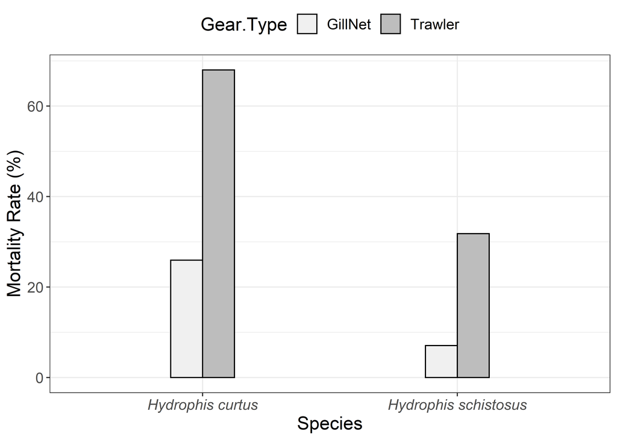

Overall (population) mortality rate is higher for both species in Trawlers and is higher overall for *H. curtus* compared to *H. schistosus*

- Should mortality be calculated at the trip level?

| Species | term | estimate | std.error | statistic | p.value | stat |
| --- | --- | --- | --- | --- | --- | --- |
| Hydrophis schistosus | (Intercept) | -2.578433 | 0.1778870 | -14.494775 | 0e+00 | 0.1131580 |
| Hydrophis schistosus | Gear.TypeTrawler | 1.815081 | 0.2120660 | 8.559038 | 0e+00 | 0.1131580 |
| Hydrophis curtus | (Intercept) | -1.048350 | 0.1993012 | -5.260131 | 1e-07 | 0.1260767 |
| Hydrophis curtus | Gear.TypeTrawler | 1.802122 | 0.3177978 | 5.670657 | 0e+00 | 0.1260767 |

| Gear.Type | term | estimate | std.error | statistic | p.value | stat |
| --- | --- | --- | --- | --- | --- | --- |
| GillNet | (Intercept) | -1.0483505 | 0.1993014 | -5.260126 | 0.0000001 | 0.0733598 |
| GillNet | SpeciesHydrophis schistosus | -1.5300823 | 0.2671420 | -5.727599 | 0.0000000 | 0.0733598 |
| Trawler | (Intercept) | 0.7537718 | 0.2475368 | 3.045090 | 0.0023261 | 0.0596262 |
| Trawler | SpeciesHydrophis schistosus | -1.5171232 | 0.2731349 | -5.554484 | 0.0000000 | 0.0596262 |

## 3.1 Effect of effort on mortality rate

| Gear.Type | Hydrophis curtus | Hydrophis schistosus |
| --- | --- | --- |
| GillNet | 48 | 208 |
| Trawler | 10 | 22 |

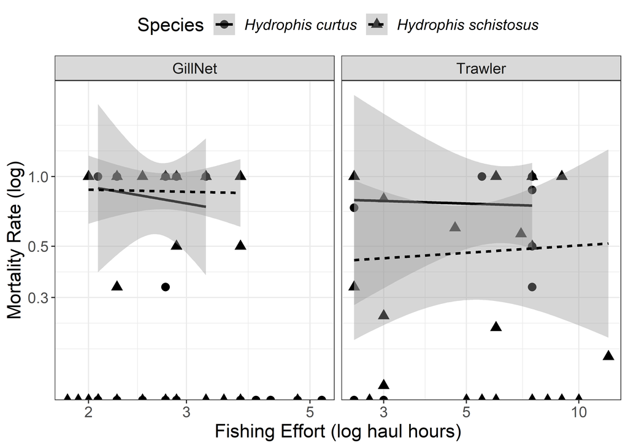

Fishing effort does not seem to have any effect on mortality rate. Samples size may be too small to infer.

| Gear.Type | Species | term | estimate | std.error | statistic | p.value | r2 |
| --- | --- | --- | --- | --- | --- | --- | --- |
| GillNet | Hydrophis curtus | (Intercept) | 0.5503717 | 1.9907468 | 0.2764649 | 0.7821910 | 0.0592452 |
| GillNet | Hydrophis curtus | fe | -0.7984762 | 0.7298936 | -1.0939625 | 0.2739714 | 0.0592452 |
| GillNet | Hydrophis schistosus | (Intercept) | -2.5659502 | 1.4267956 | -1.7984007 | 0.0721135 | 0.0000088 |
| GillNet | Hydrophis schistosus | fe | -0.0131855 | 0.5041026 | -0.0261563 | 0.9791326 | 0.0000088 |
| Trawler | Hydrophis curtus | (Intercept) | -1.6862303 | 1.5586829 | -1.0818303 | 0.2793280 | 0.2571808 |
| Trawler | Hydrophis curtus | fe | 0.1989842 | 0.2277935 | 0.8735288 | 0.3823749 | 0.2571808 |
| Trawler | Hydrophis schistosus | (Intercept) | -0.6828804 | 0.8937625 | -0.7640514 | 0.4448366 | 0.0197936 |
| Trawler | Hydrophis schistosus | fe | -0.0649642 | 0.1429426 | -0.4544780 | 0.6494848 | 0.0197936 |

# 4 Change in sea snake assemblages

Only trawlers will be considered for this part of the analysis.

## 4.1 Sampling effort accross years

| Year | N.trips | Total.fe |
| --- | --- | --- |
| 2002 | 194 | 385.00 |
| 2007 | 70 | 110.00 |
| 2016 | 5 | 34.00 |
| 2017 | 34 | 256.50 |
| 2018 | 26 | 158.66 |

Data is pooled across study period for Lobo and Padate

- Why is effort higher in original analysis?

## 4.2 Variation in CPUE of sea snakes in Trawlers

- What is the mean CPUE in each study?
- Are they accross multiple years?
- What is the total effort?
- Abundance by species?

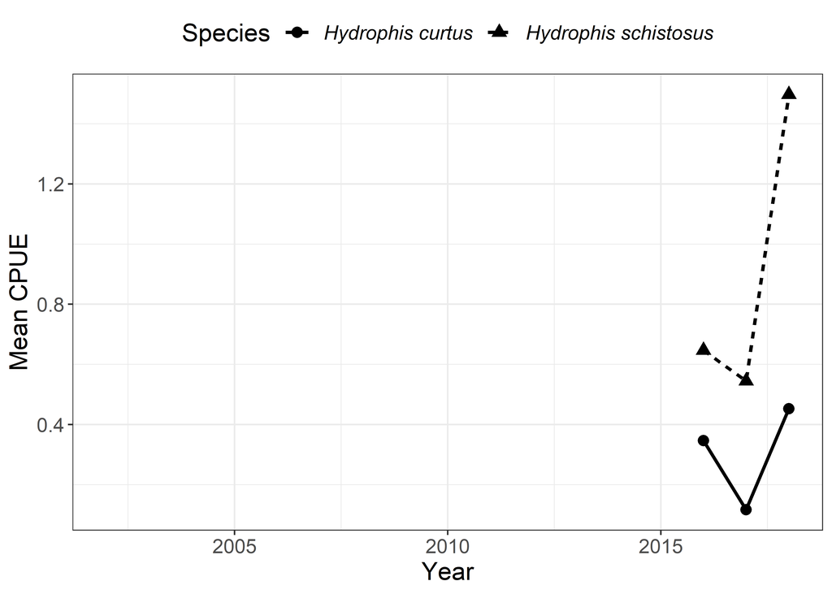

| Species | term | estimate | std.error | statistic | p.value |
| --- | --- | --- | --- | --- | --- |
| Hydrophis schistosus | Year | 0.4253471 | 0.3043681 | 1.3974758 | 0.3954066 |
| Hydrophis schistosus | (Intercept) | -857.0285114 | 613.9105494 | -1.3960153 | 0.3957217 |
| Hydrophis curtus | Year | 0.0527736 | 0.1632972 | 0.3231754 | 0.8010050 |
| Hydrophis curtus | (Intercept) | -106.1388358 | 329.3703989 | -0.3222476 | 0.8015398 |

## 4.3 Change in abundance across studies

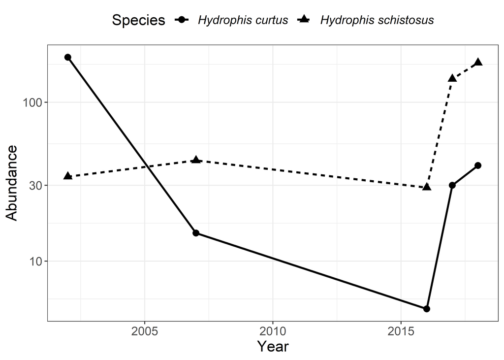

| Species | term | estimate | std.error | statistic | p.value |
| --- | --- | --- | --- | --- | --- |
| Hydrophis curtus | (Intercept) | 15843.627723 | 8677.664339 | 1.825794 | 0.1653618 |
| Hydrophis curtus | Year | -7.846535 | 4.312933 | -1.819304 | 0.1664363 |
| Hydrophis schistosus | Year | 6.549505 | 4.127547 | 1.586779 | 0.2107559 |
| Hydrophis schistosus | (Intercept) | -13093.003960 | 8304.665417 | -1.576584 | 0.2129842 |

## 4.4 Assemblage composition accross studies

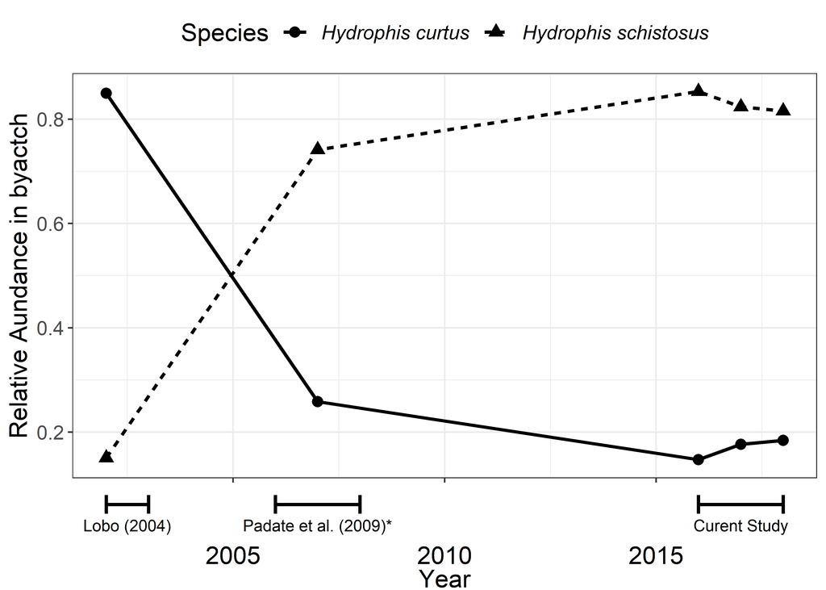

| estimate1 | estimate2 | estimate3 | estimate4 | estimate5 | statistic | p.value | r |
| --- | --- | --- | --- | --- | --- | --- | --- |
| 0.8495575 | 0.2586207 | 0.1470588 | 0.1764706 | 0.1843318 | 281.6543 | 0 | 0.3995097 |

## 4.5 Difference in mortality of sea snakes in Trawlers

| Study | Species | n.dead | N | mort.rate |
| --- | --- | --- | --- | --- |
| Lobo (2004) | Hydrophis curtus | 132 | 192 | 0.6875000 |
| Lobo (2004) | Hydrophis schistosus | 4 | 34 | 0.1176471 |
| Padate et al. (2009) | Hydrophis curtus | 15 | NA | NA |
| Padate et al. (2009) | Hydrophis schistosus | 43 | NA | NA |
| Current | Hydrophis curtus | 51 | 75 | 0.6800000 |
| Current | Hydrophis schistosus | 110 | 346 | 0.3179191 |

- n.alive, n.dead, total for each study each species

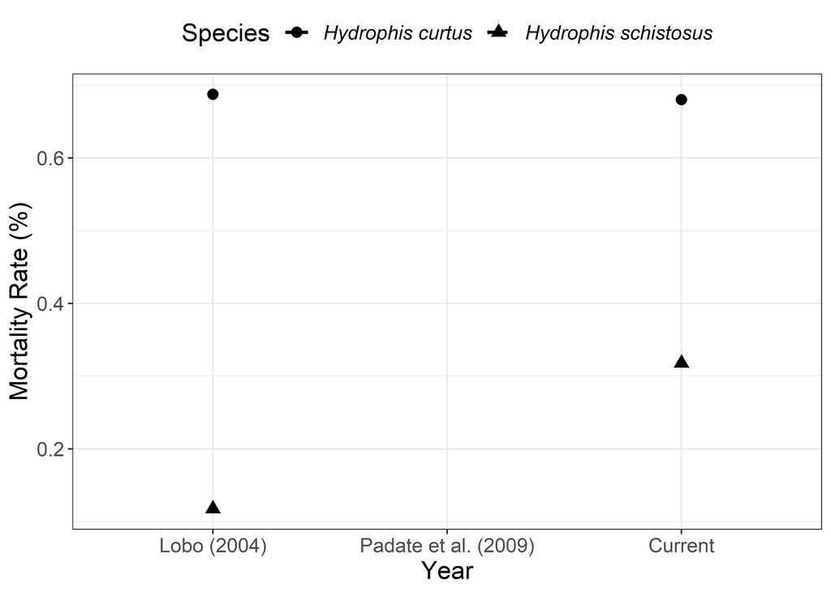

| Species | estimate1 | estimate2 | statistic | p.value | r |
| --- | --- | --- | --- | --- | --- |
| Hydrophis curtus | 0.6875000 | 0.6800000 | 0.000000 | 1.0000000 | 0.0000000 |
| Hydrophis schistosus | 0.1176471 | 0.3179191 | 4.997571 | 0.0253829 | 0.0131515 |

# 5 Increase in fishing pressure in Konkan 2000 - 2020

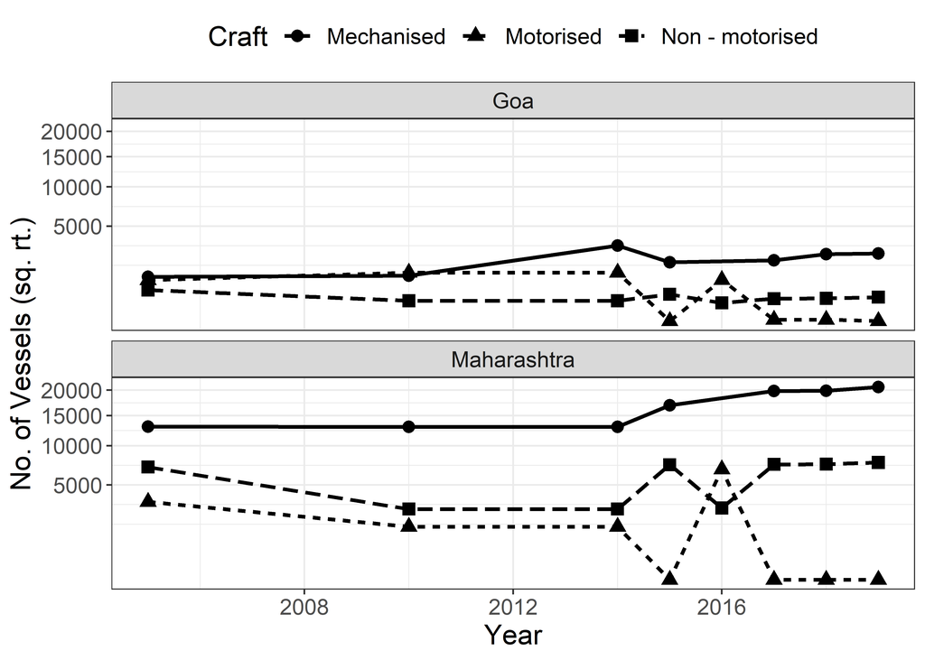

| State | Craft | term | estimate | std.error | statistic | p.value | r2 |
| --- | --- | --- | --- | --- | --- | --- | --- |
| Maharashtra | Mechanised | (Intercept) | -69.9447237 | 1.3999812 | -49.961190 | 0 | 0.7467118 |
| Maharashtra | Mechanised | Year | 0.0395470 | 0.0006949 | 56.913780 | 0 | 0.7467118 |
| Goa | Mechanised | (Intercept) | -115.4983459 | 4.2006942 | -27.495062 | 0 | 0.5441047 |
| Goa | Mechanised | Year | 0.0611171 | 0.0020846 | 29.318823 | 0 | 0.5441047 |
| Goa | Non - motorised | (Intercept) | 86.2325473 | 8.6498363 | 9.969269 | 0 | 0.3073411 |
| Goa | Non - motorised | Year | -0.0399799 | 0.0042961 | -9.306161 | 0 | 0.3073411 |
| Goa | Motorised | (Intercept) | 252.8613557 | 5.8641018 | 43.120219 | 0 | 0.2632877 |
| Goa | Motorised | Year | -0.1224781 | 0.0029154 | -42.010095 | 0 | 0.2632877 |
| Maharashtra | Motorised | (Intercept) | 185.9700181 | 3.4680508 | 53.623788 | 0 | 0.1044864 |
| Maharashtra | Motorised | Year | -0.0886872 | 0.0017235 | -51.458983 | 0 | 0.1044864 |
| Maharashtra | Non - motorised | (Intercept) | -33.6241328 | 2.2838299 | -14.722696 | 0 | 0.0459403 |
| Maharashtra | Non - motorised | Year | 0.0209820 | 0.0011336 | 18.508824 | 0 | 0.0459403 |

| Craft | estimate | estimate1 | estimate2 | statistic | p.value | d |
| --- | --- | --- | --- | --- | --- | --- |
| Mechanised | -14568.29 | 2054.429 | 16622.714 | -10.598781 | 0.0000233 | 5.6652869 |
| Non - motorised | -5365.00 | 304.625 | 5669.625 | -6.387398 | 0.0003649 | 3.1936991 |
| Motorised | -1103.25 | 558.750 | 1662.000 | -1.260113 | 0.2435439 | 0.6300565 |

# 6 Study site map

| Study | Name | lon | lat |
| --- | --- | --- | --- |
| 2016 - 2018 | Malvan | 73.47105 | 16.06307 |
| 2002 - 2003 | Chapora | 73.74337 | 15.60212 |
| 2002 - 2003 | Vasco | 73.81133 | 15.39819 |
| 2002 - 2003 | Malim Jetty | 73.83445 | 15.50495 |
| 2002 - 2003 | Betul, Ambelim | 73.95637 | 15.14703 |
| 2016 - 2018 | Vengurla | 73.63890 | 15.85141 |
| 2006-2008 | Zuari Estuary | 74.14299 | 15.24290 |
| 2006-2008 | Fort Aguada | 73.77316 | 15.49256 |
| 2006-2008 | Mormugao | 73.81657 | 15.38891 |
| 2006-2008 | Mandovi River | 73.90872 | 15.50629 |
| 2006-2008 | Cumbharjua canal | 73.94320 | 15.50904 |